# Ahmed_Report_code

#### Hi, Welcome to Our MovieLens Recommender System

#### Student No: 29799899

#### 29799899@sun.ac.za

In our code we build a recommender system from scratch using alternating least squares (ALS) for the MovieLens 32 million dataset. Our system solves (address) sparse matrix completion with 200,948 users, 84,432 movies, and only 0.19% of possible ratings observed. In any system selling products, popular products occupy one end while a long tail of content remains a heavy tail of products users do not know about but that remains monetizable. To capture this value, we build multiple ALS models starting from simple biases to complex uncertainty quantification. Each model addresses different aspects of the recommendation problem. We hope this creates value for both users discovering content and businesses monetizing their entire catalog.

##### Small Tips on How to Run Our Code

Welcome! To run our system:

1. Update the data paths to your MovieLens CSV files in the main function () the last one in our file.
2. Run the Python code cell oi

That's it! Our code wil trains all models and generates visualizations.

To start We organized our code into separate classes to make it clean and easy to work with. Each model gets its own class, which means: which help use us for instance If our BPR model has a bug, we know exactly where to look - in the BPR class. We don't need to lose our mind through thousands of lines of mixed code.

#### Our Model Classes

- **`DataLoader`**: For loading our 32 million ratings and creates the data structures we need to train our models.
- **`BiasOnly`**: Our simplest baseline using just user/item biases (0.8558 RMSE)
- **`Latent`**: Our main ALS model with embeddings for personalization (0.7716 RMSE)
- **`Features`**: Our solution for cold-start movies with genres (0.7708 RMSE)
- **`VI`**: Our model that provides uncertainty estimates (0.8460 RMSE)
- **`BPR`**: Our approach for implicit feedback when users don't rate (0.9953 AUC)

### Our libs that we imported and used to build our system with

```python
import numpy as np
import pandas as pd
import matplotlib.pyplot as plt
from scipy import stats
from sklearn.decomposition import PCA
from sklearn.metrics import roc_auc_score
import time
import random
import hashlib
import os
import pickle
import scipy.linalg

np.random.seed(42)
random.seed(42)
```

#### **DataLoader:** Here We process our MovieLens-32M dataset, creating user-item mappings and also extracting genre features for our hierarchical modeling approach with a 90-10 train-test split. We also verify our data structures integrity ensuring consistent dimensions across users, items, and identifying cold-start scenarios that we needs later on for analysis .

```python
class DataLoader:
    def __init__(self):
        self.M = 0
        self.N = 0
        self.K = 0
        self.mu = 0.0

        self.usermap = {}
        self.itemmap = {}
        self.userlist = []
        self.itemlist = []
        self.titles = {}
        self.genres = []
        self.genremap = {}
        self.genrelist = {}
        self.features = []

        self.train = []
        self.test = []
        self.trainitem = []
        self.testitem = []

        self.userdeg = []
        self.itemdeg = []
        self.counts = None

    def load(self, rpath, mpath):
        print("Loading data...")
        ratings = pd.read_csv(rpath)
        movies = pd.read_csv(mpath)

        users = sorted(ratings['userId'].unique())
        items = sorted(ratings['movieId'].unique())

        self.M = len(users)
        self.N = len(items)

        self.usermap = {uid: i for i, uid in enumerate(users)}
        self.itemmap = {mid: i for i, mid in enumerate(items)}
        self.userlist = users
        self.itemlist = items
        self.titles = dict(zip(movies['movieId'], movies['title']))

        self.processgenres(movies)
        self.split(ratings)

        self.userdeg = [len(self.train[u]) + len(self.test[u]) for u in range(self.M)]
        self.itemdeg = [len(self.trainitem[i]) + len(self.testitem[i]) for i in range(self.N)]
        self.counts = np.array(self.itemdeg)

        print(f"Loaded {self.M} users, {self.N} items, {self.K} genres")

    def processgenres(self, movies):
        allgenres = set()
        for g in movies['genres'].fillna(''):
            if g and g != '(no genres listed)':
                for genre in g.split('|'):
                    allgenres.add(genre)

        self.genres = sorted(list(allgenres)) if allgenres else ['Unknown']
        self.K = len(self.genres)
        self.genremap = {g: i for i, g in enumerate(self.genres)}
        self.genrelist = {i: g for g, i in self.genremap.items()}

        self.features = []
        for mid in self.itemlist:
            row = movies[movies['movieId'] == mid]
            if len(row) > 0:
                gstr = str(row.iloc[0]['genres'])
                if gstr != '(no genres listed)' and gstr != 'nan':
                    idxs = [self.genremap[g] for g in gstr.split('|') if g in self.genremap]
                    self.features.append(idxs)
                else:
                    self.features.append([])
            else:
                self.features.append([])

    def split(self, ratings):
        self.train = [[] for u in range(self.M)]
        self.test = [[] for u in range(self.M)]
        self.trainitem = [[] for i in range(self.N)]
        self.testitem = [[] for i in range(self.N)]

        for idx, row in ratings.iterrows():
            u = self.usermap[row['userId']]
            i = self.itemmap[row['movieId']]
            r = float(row['rating'])

            if np.random.rand() < 0.9:
                self.train[u].append((i, r))
                self.trainitem[i].append((u, r))
            else:
                self.test[u].append((i, r))
                self.testitem[i].append((u, r))

        trainratings = []
        for u in range(self.M):
            for i, r in self.train[u]:
                trainratings.append(r)
        self.mu = np.mean(trainratings) if trainratings else 3.5

    def save(self, filepath):
        with open(filepath, 'wb') as f:
            pickle.dump(self.__dict__, f)
        print(f"Data saved to {filepath}")

    def loadprocessed(self, filepath):
        with open(filepath, 'rb') as f:
            saved_data = pickle.load(f)
        self.__dict__.update(saved_data)
        print(f"Data loaded from {filepath}")


def checkconsistency(data):
    print("\n" + "="*60)
    print("DATA CONSISTENCY CHECK")
    print("="*60)

    if not hasattr(data, 'train'):
        print("Data not loaded yet. Please check file paths.")
        return False

    assert len(data.train) == data.M, "Train user data mismatch"
    assert len(data.test)  == data.M, "Test user data mismatch"
    print(f" Dimensions: {data.M} users, {data.N} items, {data.K} genres")

    traincount = sum(len(data.train[u]) for u in range(data.M))
    testcount = sum(len(data.test[u]) for u in range(data.M))
    total = traincount + testcount
    print(f" Ratings: {total:,} total ({traincount:,} train, {testcount:,} test)")

    denom = data.M * data.N
    sparsity = 100 * (1 - total / denom) if denom > 0 else float('nan')
    print(f"Sparsity: {sparsity:.2f}%")

    emptyusers = sum(1 for u in range(data.M) if len(data.train[u]) == 0)
    item_counts = [0] * data.N
    for u in range(data.M):
        for i, r in data.train[u]:
            if 0 <= i < data.N:
                item_counts[i] = item_counts[i] + 1
    cold_items = sum(1 for c in item_counts if c == 0)
    if emptyusers > 0 or cold_items > 0:
        print(f" Cold start: {emptyusers} users, {cold_items} items")

    if hasattr(data, 'mu'):
        print(f"Global mean μ: {data.mu:.3f}")
    else:
        ratings = [r for u in range(data.M) for (i, r) in data.train[u]]
        if ratings:
            mu = sum(ratings) / len(ratings)
            print(f"Global mean μ (train): {mu:.3f}")

    print("Data loaded successfully!")
    return True
```

### Our models

**BiasOnly:** Here we have our baseline model that learn only user and item biases in our f: $\hat{r}_{ui} = \mu + b_u + b_i$.

```python
class BiasOnly:
    def __init__(self, data):
        self.data = data
        self.bu = None
        self.bi = None
        self.rmsetrain = []
        self.rmsetest = []
        self.losshistory = []

    def computermse(self, dataset):
        errors = []
        for u in range(self.data.M):
            for i, r in dataset[u]:
                pred = self.data.mu + self.bu[u] + self.bi[i]
                errors.append((r - pred) ** 2)
        return np.sqrt(np.mean(errors)) if errors else 0

    def computeloss(self, dataset):
        dataterm = 0
        for u in range(self.data.M):
            for i, r in dataset[u]:
                pred = self.data.mu + self.bu[u] + self.bi[i]
                dataterm = dataterm + (r - pred) ** 2

        regterm = self.gam * (np.sum(self.bu**2) + np.sum(self.bi**2))
        return -0.5 * (self.lam * dataterm + regterm)

    def train(self, epochs=10, lam=1.0, gam=0.1):
        self.lam = lam
        self.gam = gam

        self.bu = np.zeros(self.data.M)
        self.bi = np.zeros(self.data.N)

        self.rmsetrain.append(self.computermse(self.data.train))
        self.rmsetest.append(self.computermse(self.data.test))
        self.losshistory.append(self.computeloss(self.data.train))

        print(f"Initial RMSE: Train={self.rmsetrain[0]:.4f}, Test={self.rmsetest[0]:.4f}")

        for ep in range(epochs):
            for u in range(self.data.M):
                items = self.data.train[u]
                if items:
                    residual = sum(r - self.data.mu - self.bi[i] for i, r in items)
                    self.bu[u] = lam * residual / (lam * len(items) + gam)

            for i in range(self.data.N):
                users = self.data.trainitem[i]
                if users:
                    residual = sum(r - self.data.mu - self.bu[u] for u, r in users)
                    self.bi[i] = lam * residual / (lam * len(users) + gam)

            self.rmsetrain.append(self.computermse(self.data.train))
            self.rmsetest.append(self.computermse(self.data.test))
            self.losshistory.append(self.computeloss(self.data.train))

            if (ep + 1) % 5 == 0:
                print(f"Epoch {ep+1}: Train={self.rmsetrain[-1]:.4f}, Test={self.rmsetest[-1]:.4f}")
```

#### Here we have our Latent ALS model we extend our baseline ALS to full matrix factorization with our latent factors: $\hat{r}_{ui} = \mu + b_u + b_i + \mathbf{U}_u^T \mathbf{V}_i$.

```python
class Latent:
    def __init__(self, data):
        self.data = data
        self.U = None
        self.V = None
        self.bu = None
        self.bi = None
        self.rmsetrain = []
        self.rmsetest = []
        self.losshistory = []

    def computermse(self, dataset):
        errors = []
        for u in range(self.data.M):
            for i, r in dataset[u]:
                pred = self.data.mu + self.bu[u] + self.bi[i] + np.dot(self.U[u], self.V[i])
                errors.append((r - pred) ** 2)
        return np.sqrt(np.mean(errors)) if errors else 0

    def computeloss(self, dataset):
        dataterm = 0
        for u in range(self.data.M):
            for i, r in dataset[u]:
                pred = self.data.mu + self.bu[u] + self.bi[i] + np.dot(self.U[u], self.V[i])
                dataterm = dataterm + (r - pred) ** 2

        regbias = self.gam * (np.sum(self.bu**2) + np.sum(self.bi**2))
        reguv = self.tau * (np.sum(self.U**2) + np.sum(self.V**2))
        return -0.5 * (self.lam * dataterm + regbias + reguv)

    def train(self, D=20, epochs=10, lam=0.1, gam=2.5, tau=1.0, verbose=True):
        self.D = D
        self.lam = lam
        self.gam = gam
        self.tau = tau

        np.random.seed(42)
        scale = 1.0 / np.sqrt(D)
        self.bu = np.zeros(self.data.M)
        self.bi = np.zeros(self.data.N)
        self.U = np.random.normal(0, scale, (self.data.M, D))
        self.V = np.random.normal(0, scale, (self.data.N, D))

        tauI = tau * np.eye(D)

        self.rmsetrain.append(self.computermse(self.data.train))
        self.rmsetest.append(self.computermse(self.data.test))
        self.losshistory.append(self.computeloss(self.data.train))

        if verbose:
            print(f"Initial RMSE: Train={self.rmsetrain[0]:.4f}, Test={self.rmsetest[0]:.4f}")

        for ep in range(epochs):
            start = time.time()

            for u in range(self.data.M):
                items = self.data.train[u]
                if not items:
                    continue

                iarr = np.array([i for i, r in items])
                rarr = np.array([r for i, r in items])
                pred = np.dot(self.V[iarr], self.U[u])
                residual = np.sum(rarr - self.data.mu - pred - self.bi[iarr])
                self.bu[u] = lam * residual / (lam * len(items) + gam)

                Vbatch = self.V[iarr]
                residuals = rarr - self.data.mu - self.bu[u] - self.bi[iarr]
                A = lam * Vbatch.T @ Vbatch + tauI
                b = lam * Vbatch.T @ residuals
                self.U[u] = np.linalg.solve(A, b)

            for i in range(self.data.N):
                users = self.data.trainitem[i]
                if not users:
                    continue

                uarr = np.array([u for u, r in users])
                rarr = np.array([r for u, r in users])
                pred = np.dot(self.U[uarr], self.V[i])
                residual = np.sum(rarr - self.data.mu - pred - self.bu[uarr])
                self.bi[i] = lam * residual / (lam * len(users) + gam)

                Ubatch = self.U[uarr]
                residuals = rarr - self.data.mu - self.bu[uarr] - self.bi[i]
                A = lam * Ubatch.T @ Ubatch + tauI
                b = lam * Ubatch.T @ residuals
                self.V[i] = np.linalg.solve(A, b)

            self.rmsetrain.append(self.computermse(self.data.train))
            self.rmsetest.append(self.computermse(self.data.test))
            self.losshistory.append(self.computeloss(self.data.train))

            if verbose and ((ep + 1) % 5 == 0 or ep == 0):
                print(f"Epoch {ep+1}: Time={time.time()-start:.1f}s, "
                      f"Train={self.rmsetrain[-1]:.4f}, Test={self.rmsetest[-1]:.4f}")
```

#### **Features model** Here we have our hierarchical model where we incorporate genre information through our prior to address cold-start in our system

```python
class Features:
    def __init__(self, data):
        self.data = data
        self.U = None
        self.V = None
        self.F = None
        self.bu = None
        self.bi = None
        self.rmsetrain = []
        self.rmsetest = []
        self.losshistory = []
        self.D = None

    def getfeaturemean(self, i):
        features = self.data.features[i]
        if not features:
            return np.zeros(self.D)
        return np.sum(self.F[features], axis=0) / np.sqrt(len(features))

    def computermse(self, dataset):
        errors = []
        for u in range(self.data.M):
            for i, r in dataset[u]:
                pred = self.data.mu + self.bu[u] + self.bi[i] + np.dot(self.U[u], self.V[i])
                errors.append((r - pred) ** 2)
        return np.sqrt(np.mean(errors)) if errors else 0

    def computeloss(self):
        dataterm = 0
        for u in range(self.data.M):
            for i, r in self.data.train[u]:
                pred = self.data.mu + self.bu[u] + self.bi[i] + np.dot(self.U[u], self.V[i])
                dataterm = dataterm + (r - pred) ** 2

        regbias = self.gam * (np.sum(self.bu**2) + np.sum(self.bi**2))
        regU = self.tau * np.sum(self.U**2)

        regV = 0
        for i in range(self.data.N):
            featuremean = self.getfeaturemean(i)
            regV = regV + np.sum((self.V[i] - featuremean)**2)
        regV = regV * self.tau

        regF = self.beta * np.sum(self.F**2)

        return -0.5 * (self.lam * dataterm + regbias + regU + regV + regF)

    def train(self, D=10, epochs=30, lam=0.1, tau=1.0, beta=1.0, gam=2.5):
        self.D = D
        self.lam = lam
        self.tau = tau
        self.beta = beta
        self.gam = gam

        np.random.seed(42)
        scale = 1.0 / np.sqrt(D)
        self.bu = np.zeros(self.data.M)
        self.bi = np.zeros(self.data.N)
        self.U = np.random.normal(0, scale, (self.data.M, D))
        self.V = np.random.normal(0, scale, (self.data.N, D))
        self.F = np.random.normal(0, scale, (self.data.K, D))

        print(f"\nHierarchical ALS: D={D}, λ={lam}, τ={tau}, β={beta}, γ={gam}")
        print(f"Genre features: {self.data.K} genres")

        self.rmsetrain.append(self.computermse(self.data.train))
        self.rmsetest.append(self.computermse(self.data.test))
        self.losshistory.append(self.computeloss())
        print(f"Initial: Train={self.rmsetrain[0]:.4f}, Test={self.rmsetest[0]:.4f}")

        for epoch in range(epochs):
            for u in range(self.data.M):
                items = self.data.train[u]
                if not items:
                    continue

                residual = sum(r - self.data.mu - self.bi[i] - np.dot(self.U[u], self.V[i])
                             for i, r in items)
                self.bu[u] = lam * residual / (lam * len(items) + gam)

                A = tau * np.eye(D)
                b = np.zeros(D)
                for i, r in items:
                    A = A + lam * np.outer(self.V[i], self.V[i])
                    b = b + lam * self.V[i] * (r - self.data.mu - self.bu[u] - self.bi[i])
                self.U[u] = np.linalg.solve(A, b)

            for i in range(self.data.N):
                users = self.data.trainitem[i]

                if users:
                    residual = sum(r - self.data.mu - self.bu[u] - np.dot(self.U[u], self.V[i])
                                 for u, r in users)
                    self.bi[i] = lam * residual / (lam * len(users) + gam)

                featuremean = self.getfeaturemean(i)
                A = tau * np.eye(D)
                b = tau * featuremean
                for u, r in users:
                    A = A + lam * np.outer(self.U[u], self.U[u])
                    b = b + lam * self.U[u] * (r - self.data.mu - self.bu[u] - self.bi[i])
                self.V[i] = np.linalg.solve(A, b)

            for k in range(self.data.K):
                movies = [i for i in range(self.data.N) if k in self.data.features[i]]
                if not movies:
                    continue

                numer = np.zeros(D)
                denom = beta
                for i in movies:
                    Fi = len(self.data.features[i])
                    if Fi == 0:
                        continue
                    weight = 1.0 / Fi
                    others = [f for f in self.data.features[i] if f != k]
                    residual = self.V[i]
                    if others:
                        residual = residual - np.sum(self.F[others], axis=0) / np.sqrt(Fi)
                    numer = numer + tau * residual / np.sqrt(Fi)
                    denom = denom + tau * weight
                if denom > 0:
                    self.F[k] = numer / denom

            self.rmsetrain.append(self.computermse(self.data.train))
            self.rmsetest.append(self.computermse(self.data.test))
            self.losshistory.append(self.computeloss())

            if (epoch + 1) % 10 == 0:
                print(f"Epoch {epoch+1}: Train={self.rmsetrain[-1]:.4f}, Test={self.rmsetest[-1]:.4f}")
```

#### **VI:** Here we have our variational inference model to quantify uncertainty in our predictions, where we maintain distributions over our embeddings rather than point estimates.

```python
class VI:
    def __init__(self, data):
        self.data = data
        self.rmsetrain = []
        self.rmsetest = []
        self.elbohistory = []

    def update_user_with_cholesky(self, u):
        items = self.data.train[u]
        if not items:
            return

        D = self.D

        A = self.tau * np.eye(D)
        b = np.zeros(D)

        for i, r in items:
            v_mean = self.mu_V[i]
            v_var = np.diag(self.sigma_V[i])

            A = A + self.lam * (np.outer(v_mean, v_mean) + v_var)
            b = b + self.lam * v_mean * (r - self.data.mu - self.bu[u] - self.bi[i])

        try:
            L = scipy.linalg.cholesky(A, lower=True)

            y = scipy.linalg.solve_triangular(L, b, lower=True)
            self.mu_U[u] = scipy.linalg.solve_triangular(L.T, y, lower=False)

            for d in range(D):
                e_d = np.zeros(D)
                e_d[d] = 1.0
                y_d = scipy.linalg.solve_triangular(L, e_d, lower=True)
                inv_col = scipy.linalg.solve_triangular(L.T, y_d, lower=False)
                self.sigma_U[u, d] = inv_col[d]

        except np.linalg.LinAlgError:
            A = A + np.eye(D)
            L = scipy.linalg.cholesky(A, lower=True)
            y = scipy.linalg.solve_triangular(L, b, lower=True)
            self.mu_U[u] = scipy.linalg.solve_triangular(L.T, y, lower=False)
            self.sigma_U[u] = np.ones(D) / np.diag(A)

    def update_item_with_cholesky(self, i):
        users = self.data.trainitem[i]
        if not users:
            return

        D = self.D

        A = self.tau * np.eye(D)
        b = np.zeros(D)

        for u, r in users:
            u_mean = self.mu_U[u]
            u_var = np.diag(self.sigma_U[u])

            A = A + self.lam * (np.outer(u_mean, u_mean) + u_var)
            b = b + self.lam * u_mean * (r - self.data.mu - self.bu[u] - self.bi[i])

        try:
            L = scipy.linalg.cholesky(A, lower=True)

            y = scipy.linalg.solve_triangular(L, b, lower=True)
            self.mu_V[i] = scipy.linalg.solve_triangular(L.T, y, lower=False)

            for d in range(D):
                e_d = np.zeros(D)
                e_d[d] = 1.0
                y_d = scipy.linalg.solve_triangular(L, e_d, lower=True)
                inv_col = scipy.linalg.solve_triangular(L.T, y_d, lower=False)
                self.sigma_V[i, d] = inv_col[d]

        except np.linalg.LinAlgError:
            A = A + np.eye(D) * 1e-6
            L = scipy.linalg.cholesky(A, lower=True)
            y = scipy.linalg.solve_triangular(L, b, lower=True)
            self.mu_V[i] = scipy.linalg.solve_triangular(L.T, y, lower=False)
            self.sigma_V[i] = np.ones(D) / np.diag(A)

    def computermse(self, dataset):
        errors = []
        for u in range(self.data.M):
            for i, r in dataset[u]:
                pred = self.data.mu + self.bu[u] + self.bi[i] + np.dot(self.mu_U[u], self.mu_V[i])
                error = r - pred
                errors.append(error * error)
        if errors:
            return np.sqrt(np.mean(errors))
        else:
            return 0

    def computeelbo(self):
        dataterm = 0.0
        for u in range(self.data.M):
            for i, r in self.data.train[u]:
                mean_pred = self.data.mu + self.bu[u] + self.bi[i] + np.dot(self.mu_U[u], self.mu_V[i])
                var_pred = np.sum(self.sigma_U[u] * self.mu_V[i] * self.mu_V[i])
                var_pred = var_pred + np.sum(self.mu_U[u] * self.mu_U[u] * self.sigma_V[i])
                var_pred = var_pred + np.sum(self.sigma_U[u] * self.sigma_V[i])
                residual = r - mean_pred
                dataterm = dataterm - 0.5 * self.lam * (residual * residual + var_pred)

        kl_u = 0.0
        for u in range(self.data.M):
            kl_u = kl_u + 0.5 * self.tau * np.sum(self.mu_U[u] * self.mu_U[u])
            kl_u = kl_u + 0.5 * self.tau * np.sum(self.sigma_U[u])
            kl_u = kl_u - 0.5 * np.sum(np.log(self.sigma_U[u] + 1e-10))
            kl_u = kl_u - 0.5 * self.D

        kl_v = 0.0
        for i in range(self.data.N):
            kl_v = kl_v + 0.5 * self.tau * np.sum(self.mu_V[i] * self.mu_V[i])
            kl_v = kl_v + 0.5 * self.tau * np.sum(self.sigma_V[i])
            kl_v = kl_v - 0.5 * np.sum(np.log(self.sigma_V[i] + 1e-10))
            kl_v = kl_v - 0.5 * self.D

        return dataterm - kl_u - kl_v

    def train(self, D=20, epochs=50, lam=0.1, tau=1.0, gam=2.5, verbose=True):
        self.D = D
        self.lam = lam
        self.tau = tau
        self.gam = gam

        np.random.seed(42)
        scale = 1.0 / np.sqrt(D)

        self.mu_U = np.random.normal(0, scale, (self.data.M, D))
        self.mu_V = np.random.normal(0, scale, (self.data.N, D))
        self.sigma_U = np.ones((self.data.M, D)) * scale * scale
        self.sigma_V = np.ones((self.data.N, D)) * scale * scale
        self.bu = np.zeros(self.data.M)
        self.bi = np.zeros(self.data.N)

        self.rmsetrain.append(self.computermse(self.data.train))
        self.rmsetest.append(self.computermse(self.data.test))
        self.elbohistory.append(self.computeelbo())

        if verbose:
            print(f"\nVariational Inference with Cholesky")
            print(f"D={D}, λ={lam}, τ={tau}, γ={gam}")
            print(f"Initial RMSE: Train={self.rmsetrain[0]:.4f}, Test={self.rmsetest[0]:.4f}")

        for epoch in range(epochs):
            start = time.time()

            for u in range(self.data.M):
                items = self.data.train[u]
                if items:
                    residual = 0
                    for i, r in items:
                        pred = self.data.mu + self.bi[i] + np.dot(self.mu_U[u], self.mu_V[i])
                        residual = residual + (r - pred)
                    self.bu[u] = lam * residual / (lam * len(items) + gam)

            for i in range(self.data.N):
                users = self.data.trainitem[i]
                if users:
                    residual = 0
                    for u, r in users:
                        pred = self.data.mu + self.bu[u] + np.dot(self.mu_U[u], self.mu_V[i])
                        residual = residual + (r - pred)
                    self.bi[i] = lam * residual / (lam * len(users) + gam)

            for u in range(self.data.M):
                self.update_user_with_cholesky(u)

            for i in range(self.data.N):
                self.update_item_with_cholesky(i)

            self.rmsetrain.append(self.computermse(self.data.train))
            self.rmsetest.append(self.computermse(self.data.test))
            self.elbohistory.append(self.computeelbo())

            if verbose and ((epoch + 1) % 10 == 0 or epoch == 0):
                elbo = self.elbohistory[-1]
                train_rmse = self.rmsetrain[-1]
                test_rmse = self.rmsetest[-1]
                elapsed = time.time() - start
                print(f"Epoch {epoch+1}: Time={elapsed:.1f}s, Train={train_rmse:.4f}, Test={test_rmse:.4f}, ELBO={elbo:.0f}")

    def predict_with_uncertainty(self, u, i):
        mean = self.data.mu + self.bu[u] + self.bi[i] + np.dot(self.mu_U[u], self.mu_V[i])

        var = np.sum(self.sigma_U[u] * self.mu_V[i] * self.mu_V[i])
        var = var + np.sum(self.mu_U[u] * self.mu_U[u] * self.sigma_V[i])
        var = var + np.sum(self.sigma_U[u] * self.sigma_V[i])

        if var > 0:
            std = np.sqrt(var)
        else:
            std = 0.0

        return mean, std

    def recommend_with_uncertainty(self, user_id, topk=10):
        scores = []

        for item_id in range(self.data.N):
            if hasattr(self.data, 'counts'):
                if self.data.counts[item_id] >= 50:
                    mean_score = np.dot(self.mu_U[user_id], self.mu_V[item_id])

                    var_penalty = np.sum(self.sigma_U[user_id] * self.sigma_V[item_id])

                    final_score = mean_score - 0.5 * var_penalty + 0.1 * self.bi[item_id]
                    scores.append((item_id, final_score))
            else:
                mean_score = np.dot(self.mu_U[user_id], self.mu_V[item_id])
                var_penalty = np.sum(self.sigma_U[user_id] * self.sigma_V[item_id])
                final_score = mean_score - 0.5 * var_penalty + 0.1 * self.bi[item_id]
                scores.append((item_id, final_score))

        scores.sort(key=lambda x: x[1], reverse=True)

        recommendations = []
        for idx, (item_id, score) in enumerate(scores[:topk]):
            if hasattr(self.data, 'itemlist') and hasattr(self.data, 'titles'):
                movie_id = self.data.itemlist[item_id]
                title = self.data.titles.get(movie_id, "Unknown")
                recommendations.append((movie_id, title, score))
            else:
                recommendations.append((item_id, f"Item {item_id}", score))

        return recommendations
```

#### **BPR:** Here we have our Bayesian Personalized Ranking model where we optimize for ranking, maximizing the difference between observed and unobserved preferences in our dataset to address implicit feedback.

```python
class BPR:
    def __init__(self, nusers, nitems, factors=50, lr=0.01, regu=0.01, regi=0.01):
        self.nusers = nusers
        self.nitems = nitems
        self.factors = factors
        self.lr = lr
        self.regu = regu
        self.regi = regi

        np.random.seed(42)
        random.seed(42)

        initstd = 0.1
        self.U = np.random.normal(0, initstd, (nusers, factors))
        self.V = np.random.normal(0, initstd, (nitems, factors))

        self.losses = []
        self.aucs = []

    def sigmoid(self, x):
        x = np.clip(x, -500, 500)
        return 1.0 / (1.0 + np.exp(-x))

    def predict(self, user, item):
        return np.dot(self.U[user], self.V[item])

    def sampleneg(self, user, positems, maxattempts=50):
        for attempt in range(maxattempts):
            neg = random.randint(0, self.nitems - 1)
            if neg not in positems:
                return neg

        allitems = set(range(self.nitems))
        negcandidates = list(allitems - positems)
        if negcandidates:
            return random.choice(negcandidates)
        else:
            return random.randint(0, self.nitems - 1)

    def update(self, user, positem, negitem):
        pospred = self.predict(user, positem)
        negpred = self.predict(user, negitem)
        xuij = pospred - negpred
        sigmoidval = self.sigmoid(xuij)
        error = 1.0 - sigmoidval

        uf = self.U[user].copy()
        iF = self.V[positem].copy()
        jf = self.V[negitem].copy()

        self.U[user] = self.U[user] + self.lr * (error * (iF - jf) - self.regu * uf)
        self.V[positem] = self.V[positem] + self.lr * (error * uf - self.regi * iF)
        self.V[negitem] = self.V[negitem] + self.lr * (-error * uf - self.regi * jf)

        loss = -np.log(sigmoidval + 1e-10) + 0.5 * self.regu * np.sum(uf**2)
        loss = loss + 0.5 * self.regi * (np.sum(iF**2) + np.sum(jf**2))

        return loss

    def fit(self, traindata, testdata=None, epochs=100, verbose=True, evalevery=10):
        useritems = {}
        for user in range(len(traindata)):
            useritems[user] = set([item for item, rating in traindata[user]])

        activeusers = [u for u in useritems.keys() if len(useritems[u]) > 0]

        if verbose:
            print(f"Training BPR for {epochs} epochs on {len(activeusers)} active users")

        initiallr = self.lr

        for epoch in range(epochs):
            epochstart = time.time()
            epochloss = 0.0
            numupdates = 0

            if epoch > 0:
                self.lr = initiallr * (0.98 ** epoch)

            random.shuffle(activeusers)

            for user in activeusers:
                positems = useritems[user]
                if len(positems) == 0:
                    continue

                numsamples = min(len(positems) * 5, 50)

                for sample in range(numsamples):
                    positem = random.choice(list(positems))
                    negitem = self.sampleneg(user, positems)

                    loss = self.update(user, positem, negitem)
                    epochloss = epochloss + loss
                    numupdates = numupdates + 1

            avgloss = epochloss / max(numupdates, 1)
            self.losses.append(avgloss)

            if testdata is not None and (epoch + 1) % evalevery == 0:
                auc = self.evalauc(testdata, useritems)
                self.aucs.append(auc)

                if verbose:
                    epochtime = time.time() - epochstart
                    print(f"Epoch {epoch+1:3d}/{epochs} | Time: {epochtime:.1f}s | "
                          f"Loss: {avgloss:.4f} | AUC: {auc:.4f}")
            elif verbose and (epoch + 1) % 10 == 0:
                epochtime = time.time() - epochstart
                print(f"Epoch {epoch+1:3d}/{epochs} | Time: {epochtime:.1f}s | "
                      f"Loss: {avgloss:.4f}")

    def evalauc(self, testdata, traindata, numsamples=1000):
        testuseritems = {}
        for user in range(len(testdata)):
            testuseritems[user] = set([item for item, rating in testdata[user]])

        ytrue = []
        yscores = []

        userswithtest = [u for u in testuseritems.keys() if len(testuseritems[u]) > 0]

        for sample in range(numsamples):
            if not userswithtest:
                break

            user = random.choice(userswithtest)

            if len(testuseritems[user]) > 0:
                positem = random.choice(list(testuseritems[user]))

                alluseritems = traindata.get(user, set()) | testuseritems.get(user, set())
                negitem = self.sampleneg(user, alluseritems)

                posscore = self.predict(user, positem)
                negscore = self.predict(user, negitem)

                ytrue.extend([1, 0])
                yscores.extend([posscore, negscore])

        if len(ytrue) > 0:
            return roc_auc_score(ytrue, yscores)
        else:
            return 0.5

def evalpr(model, testdata, traindata, kvalues=[5, 10, 20]):
    results = {}

    for k in kvalues:
        precisions = []
        recalls = []

        for user in range(len(testdata)):
            testitems = set([item for item, rating in testdata[user]])
            if len(testitems) == 0:
                continue

            trainitems = set([item for item, rating in traindata[user]])
            candidateitems = [i for i in range(model.nitems) if i not in trainitems]

            scores = [(item, model.predict(user, item)) for item in candidateitems]
            scores.sort(key=lambda x: x[1], reverse=True)
            recommendations = set([item for item, score in scores[:k]])

            if len(recommendations) > 0:
                precision = len(recommendations & testitems) / len(recommendations)
                precisions.append(precision)

            if len(testitems) > 0:
                recall = len(recommendations & testitems) / len(testitems)
                recalls.append(recall)

        results[f'precision@{k}'] = np.mean(precisions) if precisions else 0.0
        results[f'recall@{k}'] = np.mean(recalls) if recalls else 0.0

    return results
```

### Our ABTesting to do Controlled Experiments , Here we use We use deterministic hashing for consistent user assignment.

```python
class ABTest:
    def __init__(self, data):
        self.data = data
        self.resultsA = []
        self.resultsB = []

    def hashuser(self, userid):
        hashobj = hashlib.sha256(str(userid).encode())
        hashdigest = hashobj.hexdigest()
        return 'A' if int(hashdigest[:2], 16) < 128 else 'B'

    def getrecommendations(self, model, useridx, topk=10, variant='control'):
        scores = []

        for i in range(self.data.N):
            pred = self.data.mu + model.bu[useridx] + model.bi[i]

            if hasattr(model, 'U') and hasattr(model, 'V'):
                pred = pred + np.dot(model.U[useridx], model.V[i])

            if variant == 'test':
                if hasattr(model, 'F') and self.data.features[i]:
                    genreboost = 1.0 + 0.1 * len(self.data.features[i])
                    pred = pred * genreboost

            scores.append((i, pred))

        scores.sort(key=lambda x: x[1], reverse=True)
        return [i for i, score in scores[:topk]]

    def simulateinteraction(self, useridx, model, variant='control'):
        recommendations = self.getrecommendations(model, useridx, topk=10, variant=variant)

        simulatedratings = []
        for itemidx in recommendations:
            pred = self.data.mu + model.bu[useridx] + model.bi[itemidx]
            if hasattr(model, 'U') and hasattr(model, 'V'):
                pred = pred + np.dot(model.U[useridx], model.V[itemidx])

            rating = np.clip(pred + np.random.normal(0, 0.5), 1, 5)
            simulatedratings.append(rating)

        return np.mean(simulatedratings)

    def runtest(self, model, nusers=100, verbose=True):
        if verbose:
            print("\n" + "="*60)
            print("A/B TEST SIMULATION")
            print("="*60)

        self.resultsA = []
        self.resultsB = []

        testusers = np.random.choice(self.data.M, min(nusers, self.data.M), replace=False)

        for useridx in testusers:
            userid = self.data.userlist[useridx]
            group = self.hashuser(userid)

            if group == 'A':
                metric = self.simulateinteraction(useridx, model, variant='control')
                self.resultsA.append(metric)
            else:
                metric = self.simulateinteraction(useridx, model, variant='test')
                self.resultsB.append(metric)

        tstat, pvalue = stats.ttest_ind(self.resultsA, self.resultsB)

        if verbose:
            print(f"Group A (Control, n={len(self.resultsA)}): Mean={np.mean(self.resultsA):.4f}")
            print(f"Group B (Test, n={len(self.resultsB)}): Mean={np.mean(self.resultsB):.4f}")
            print(f"T-statistic: {tstat:.4f}")
            print(f"P-value: {pvalue:.4f}")

            if pvalue < 0.05:
                winner = 'A' if np.mean(self.resultsA) > np.mean(self.resultsB) else 'B'
                print(f" Model {winner} is significantly better (p < 0.05)")
            else:
                print(" No significant difference")

        return {'tstat': tstat, 'pvalue': pvalue}
```

#### Our Recommender Here we do our main interface for generating personalized recommendations based on our learned embeddings from our models.

```python
class Recommender:
    def __init__(self, model, data):
        self.model = model
        self.data = data

    def recommendformovie(self, movieid, topk=10):
        if movieid not in self.data.itemmap:
            print(f"Movie {movieid} not found")
            return []

        idx = self.data.itemmap[movieid]
        title = self.data.titles.get(movieid, "Unknown")
        print(f"\nRecommendations for users who liked: {title}")
        print("-" * 60)

        if hasattr(self.model, 'V'):
            dummyu = self.model.V[idx].copy()
        else:
            print("Model doesn't have item vectors")
            return []

        scores = []
        for i in range(self.data.N):
            if self.data.counts[i] >= 50:
                score = np.dot(dummyu, self.model.V[i])
                if hasattr(self.model, 'bi'):
                    score = score + 0.1 * self.model.bi[i]
                scores.append((i, score))

        scores.sort(key=lambda x: x[1], reverse=True)

        recommendations = []
        for rank, (i, score) in enumerate(scores[:topk], 1):
            mid = self.data.itemlist[i]
            title = self.data.titles.get(mid, "Unknown")[:60]
            print(f"{rank:2}. {title:<60} | Score: {score:.3f}")
            recommendations.append((mid, title, score))

        return recommendations
```

### Our ALS moddels visulaisation functions:

#### **plotdistributions():** We show how users rate movies and how many ratings each movie gets.

```python
def plotdistributions(data):
    fig, axes = plt.subplots(2, 2, figsize=(12, 10))

    axes[0,0].hist(data.userdeg, bins=50, edgecolor='black', alpha=0.7)
    axes[0,0].set_xlabel('Number of Ratings')
    axes[0,0].set_ylabel('Number of Users')
    axes[0,0].set_title('User Activity Distribution')
    axes[0,0].axvline(np.mean(data.userdeg), color='red', linestyle='--',
                      label=f'Mean: {np.mean(data.userdeg):.1f}')
    axes[0,0].legend()
    axes[0,0].grid(True, alpha=0.3)

    axes[0,1].hist(data.itemdeg, bins=50, edgecolor='black', alpha=0.7, color='orange')
    axes[0,1].set_xlabel('Number of Ratings')
    axes[0,1].set_ylabel('Number of Items')
    axes[0,1].set_title('Item Popularity Distribution')
    axes[0,1].axvline(np.mean(data.itemdeg), color='red', linestyle='--',
                      label=f'Mean: {np.mean(data.itemdeg):.1f}')
    axes[0,1].legend()
    axes[0,1].grid(True, alpha=0.3)

    allratings = []
    for u in range(data.M):
        allratings.extend([r for i, r in data.train[u]])
        allratings.extend([r for i, r in data.test[u]])

    ratingcounts = pd.Series(allratings).value_counts().sort_index()
    axes[1,0].bar(ratingcounts.index, ratingcounts.values, edgecolor='black')
    axes[1,0].set_xlabel('Rating Value')
    axes[1,0].set_ylabel('Count')
    axes[1,0].set_title('Rating Distribution')
    axes[1,0].grid(True, alpha=0.3)

    traincount = sum(len(data.train[u]) for u in range(data.M))
    testcount = sum(len(data.test[u]) for u in range(data.M))
    sparsity = 100 * (1 - len(allratings) / (data.M * data.N))

    statstext = f"""Dataset Summary:

Users: {data.M:,}
Items: {data.N:,}
Genres: {data.K}

Train: {traincount:,}
Test: {testcount:,}
Total: {len(allratings):,}

Sparsity: {sparsity:.2f}%
μ: {data.mu:.3f}"""

    axes[1,1].text(0.1, 0.5, statstext, transform=axes[1,1].transAxes,
                   fontsize=11, verticalalignment='center', fontfamily='monospace')
    axes[1,1].axis('off')

    plt.suptitle('Dataset Distributions', fontsize=14, fontweight='bold')
    plt.tight_layout()
    plt.show()
```

#### **plotpowerlaws():** We show that few users contribute most ratings while most users provide few ratings.

```python
def plotpowerlaws(data):
    fig, axes = plt.subplots(1, 2, figsize=(12, 5))

    usercounts = pd.Series(data.userdeg).value_counts().sort_index()
    validuser = usercounts[usercounts.index > 0]
    if len(validuser) > 1:
        xuser = np.log10(validuser.index.values)
        yuser = np.log10(validuser.values)
        mask = np.isfinite(xuser) & np.isfinite(yuser)
        if np.sum(mask) > 1:
            xuser = xuser[mask]
            yuser = yuser[mask]
            axes[0].scatter(xuser, yuser, alpha=0.6)
            z = np.polyfit(xuser, yuser, 1)
            p = np.poly1d(z)
            axes[0].plot(xuser, p(xuser), "r-", alpha=0.8, label=f'Slope: {z[0]:.2f}')
            axes[0].set_xlabel('log10(Degree)')
            axes[0].set_ylabel('log10(Count)')
            axes[0].set_title('User Power Law Distribution')
            axes[0].legend()
            axes[0].grid(True, alpha=0.3)

    itemcounts = pd.Series(data.itemdeg).value_counts().sort_index()
    validitem = itemcounts[itemcounts.index > 0]
    if len(validitem) > 1:
        xitem = np.log10(validitem.index.values)
        yitem = np.log10(validitem.values)
        mask = np.isfinite(xitem) & np.isfinite(yitem)
        if np.sum(mask) > 1:
            xitem = xitem[mask]
            yitem = yitem[mask]
            axes[1].scatter(xitem, yitem, alpha=0.6, color='orange')
            z = np.polyfit(xitem, yitem, 1)
            p = np.poly1d(z)
            axes[1].plot(xitem, p(xitem), "r-", alpha=0.8, label=f'Slope: {z[0]:.2f}')
            axes[1].set_xlabel('log10(Degree)')
            axes[1].set_ylabel('log10(Count)')
            axes[1].set_title('Item Power Law Distribution')
            axes[1].legend()
            axes[1].grid(True, alpha=0.3)

    plt.suptitle('Power Law Analysis', fontsize=14, fontweight='bold')
    plt.tight_layout()
    plt.show()
```

#### **plotcurves():** We plot training and test errors to see if our model is learning.

```python
def plotcurves(model, title):
    fig, axes = plt.subplots(1, 2, figsize=(12, 5))

    epochs = range(len(model.rmsetrain))
    axes[0].plot(epochs, model.rmsetrain, 'b-o', label='Train', markersize=4)
    axes[0].plot(epochs, model.rmsetest, 'r-o', label='Test', markersize=4)
    axes[0].set_xlabel('Epoch')
    axes[0].set_ylabel('RMSE')
    axes[0].set_title(f'{title} - RMSE')
    axes[0].legend()
    axes[0].grid(True, alpha=0.3)

    axes[1].plot(model.losshistory, 'g-', linewidth=2)
    axes[1].set_xlabel('Epoch')
    axes[1].set_ylabel('Negative Log-Likelihood')
    axes[1].set_title(f'{title} - Loss (Should Increase)')
    axes[1].grid(True, alpha=0.3)

    isincreasing = all(model.losshistory[i] <= model.losshistory[i+1]
                       for i in range(len(model.losshistory)-1))
    status = " Monotonically increasing" if isincreasing else " Not monotonic"
    axes[1].text(0.02, 0.98, status, transform=axes[1].transAxes,
                fontsize=10, verticalalignment='top',
                color='green' if isincreasing else 'red')

    plt.tight_layout()
    plt.show()
```

#### **plotembeddings2d():** Here we visualize our learned movie embeddings in 2D space, To show genre-based clustering in our model.

```python
def plotembeddings2d(model, data):
    if not hasattr(model, "V"):
        print("Model has no V")
        return

    V = model.V
    if V.shape[1] >= 2:
        V2d = V[:, :2]
    else:
        return 0
    uniquegenres = set()
    for i in range(data.N):
        if data.features[i]:
            primarygenreidx = data.features[i][0]
            uniquegenres.add(primarygenreidx)

    genrelist = sorted(list(uniquegenres))
    colors = plt.cm.tab20(np.linspace(0, 1, max(1, min(20, len(genrelist)))))
    genrecolors = {g: colors[i % 20] for i, g in enumerate(genrelist)}
    if hasattr(data, "counts") and data.counts is not None:
        popular = [i for i in range(data.N) if data.counts[i] >= 100]
    else:
        popular = list(range(data.N))

    plt.figure(figsize=(12, 8))
    plottedgenres = set()

    horrorexample = None
    childrenexample = None

    for i in popular[:1000]:
        if not data.features[i]:
            continue

        primarygenreidx = data.features[i][0]
        genrename = data.genres[primarygenreidx]
        color = genrecolors.get(primarygenreidx, 'gray')
        x = V2d[i, 0] + (0.1 * model.bi[i] if hasattr(model, "bi") else 0.0)
        y = V2d[i, 1]

        if genrename == 'Horror' and horrorexample is None:
            horrorexample = (x, y, data.titles.get(data.itemlist[i], "Unknown")[:30])
        if genrename == 'Children' and childrenexample is None:
            childrenexample = (x, y, data.titles.get(data.itemlist[i], "Unknown")[:30])

        if primarygenreidx not in plottedgenres and len(plottedgenres) < 15:
            plt.scatter(x, y, c=[color], alpha=0.6, s=30, label=genrename)
            plottedgenres.add(primarygenreidx)
        else:
            plt.scatter(x, y, c=[color], alpha=0.6, s=30)
    if horrorexample:
        plt.annotate(f"Horror: {horrorexample[2]}",
                    (horrorexample[0], horrorexample[1]),
                    xytext=(10, 10), textcoords='offset points',
                    bbox=dict(boxstyle='round,pad=0.5', fc='yellow', alpha=0.5),
                    arrowprops=dict(arrowstyle='->', connectionstyle='arc3,rad=0'),
                    fontsize=8)

    if childrenexample:
        plt.annotate(f"Children: {childrenexample[2]}",
                    (childrenexample[0], childrenexample[1]),
                    xytext=(-10, -10), textcoords='offset points',
                    bbox=dict(boxstyle='round,pad=0.5', fc='lightblue', alpha=0.5),
                    arrowprops=dict(arrowstyle='->', connectionstyle='arc3,rad=0'),
                    fontsize=8)

    plt.title('2D Movie Embeddings - Similar Movies Cluster Together', fontsize=14, fontweight='bold')
    plt.xlabel('Latent Dimension 1 (with bias adjustment)')
    plt.ylabel('Latent Dimension 2')
    if plottedgenres:
        plt.legend(fontsize=8, loc='best', ncol=2)
    plt.grid(True, alpha=0.3)
    plt.tight_layout()
    plt.show()
```

#### **plotfeatureembeddings():** We show where each genre lands in our learned space.

```python
def plotfeatureembeddings(model, data):
    if model.F.shape[1] >= 2:
        F2d = model.F[:, :2]
    else:
        return 0
    colors = plt.cm.tab20(np.linspace(0, 1, data.K))
    plt.figure(figsize=(7, 6))

    for k in range(data.K):
        plt.scatter(F2d[k, 0], F2d[k, 1], c=[colors[k]], s=80, alpha=0.7)
        plt.annotate(data.genrelist[k][:10], (F2d[k, 0], F2d[k, 1]),
                     xytext=(2, 2), textcoords='offset points', fontsize=7)

    plt.scatter(0, 0, c='red', s=100, marker='x', label='Zero Prior')
    plt.xlabel('Dimension 1')
    plt.ylabel('Dimension 2')
    plt.title('Feature Embeddings (Genres)')
    plt.legend()
    plt.grid(True, alpha=0.3)
    plt.show()
```

```python
def plotmovieembeddings(model, data, maxmovies= 500):
    if model.V.shape[1] >= 2:
        V2d = model.V[:, :2]
    else:
        return 0

    colors = plt.cm.tab20(np.linspace(0, 1, data.K))
    fig, ax = plt.subplots(figsize=(10, 8))

    scatterhandles = {}
    for i in range(min(maxmovies, data.N)):
        if data.features[i]:
            genreidx = data.features[i][0]
            color = colors[genreidx % len(colors)]
            point = ax.scatter(V2d[i, 0], V2d[i, 1], c=[color], s=10, alpha=0.5)
            if genreidx not in scatterhandles:
                scatterhandles[genreidx] = point

    legendlabels = [data.genrelist[g][:12] for g in scatterhandles.keys()]
    ax.legend(scatterhandles.values(), legendlabels,
              bbox_to_anchor=(1.05, 1), loc='upper left', fontsize=7, ncol=1)

    ax.set_xlabel('Dimension 1')
    ax.set_ylabel('Dimension 2')
    ax.set_title('Movie Embeddings by Primary Genre')
    ax.grid(True, alpha=0.3)
    plt.tight_layout()
    plt.show()
```

#### **plotbpr():** We track how well our BPR ranking model learns over time.

```python
def plotbpr(bprmodel, prresults):
    fig, axes = plt.subplots(1, 3, figsize=(15, 5))

    axes[0].plot(bprmodel.losses, 'b-', linewidth=2)
    axes[0].set_xlabel('Epoch')
    axes[0].set_ylabel('BPR Loss')
    axes[0].set_title('BPR Training Loss')
    axes[0].grid(True, alpha=0.3)

    kvalues = [5, 10, 20]
    precisions = [prresults[f'precision@{k}'] for k in kvalues]
    axes[1].plot(kvalues, precisions, 'g-o', markersize=8)
    axes[1].set_xlabel('k')
    axes[1].set_ylabel('Precision@k')
    axes[1].set_title('Precision at k')
    axes[1].grid(True, alpha=0.3)

    recalls = [prresults[f'recall@{k}'] for k in kvalues]
    axes[2].plot(kvalues, recalls, 'r-o', markersize=8)
    axes[2].set_xlabel('k')
    axes[2].set_ylabel('Recall@k')
    axes[2].set_title('Recall at k')
    axes[2].grid(True, alpha=0.3)

    plt.suptitle('BPR Performance Metrics', fontsize=14, fontweight='bold')
    plt.tight_layout()
    plt.show()
```

#### **plotdimensions():** We test different numbers of dimensions to find the best one.

```python
def plotdimensions(results):
    Dvalues = sorted(results.keys())
    trainrmse = [results[d]['train'] for d in Dvalues]
    testrmse = [results[d]['test'] for d in Dvalues]

    plt.figure(figsize=(10, 6))
    plt.plot(Dvalues, trainrmse, 'b-o', label='Train', linewidth=2, markersize=8)
    plt.plot(Dvalues, testrmse, 'r-s', label='Test', linewidth=2, markersize=8)
    plt.xlabel('Number of Latent Dimensions (D)')
    plt.ylabel('RMSE')
    plt.title('Choosing Optimal Latent Dimensions - Diminishing Returns Analysis')
    plt.legend()
    plt.grid(True, alpha=0.3)

    bestd = min(results.keys(), key=lambda d: results[d]['test'])
    plt.axvline(x=bestd, color='green', linestyle='--', alpha=0.5)
    plt.text(bestd, min(testrmse), f' Best: D={bestd}', fontsize=10)

    plt.tight_layout()
    plt.show()
```

#### **plotabtest():** We plot to compare two versions of our system to see which users prefer.

```python
def plotabtest(abtest):
    fig, axes = plt.subplots(1, 2, figsize=(12, 5))

    axes[0].hist(abtest.resultsA, bins=20, alpha=0.6, label='Control', color='blue')
    axes[0].hist(abtest.resultsB, bins=20, alpha=0.6, label='Test', color='red')
    axes[0].set_xlabel('Average Rating')
    axes[0].set_ylabel('Frequency')
    axes[0].set_title('A/B Test Distributions')
    axes[0].legend()
    axes[0].grid(True, alpha=0.3)

    means = [np.mean(abtest.resultsA), np.mean(abtest.resultsB)]
    stds = [np.std(abtest.resultsA), np.std(abtest.resultsB)]

    axes[1].bar(['Control', 'Test'], means, yerr=stds, capsize=10,
               color=['blue', 'red'], alpha=0.7)
    axes[1].set_ylabel('Mean Rating')
    axes[1].set_title('Mean Performance')
    axes[1].grid(True, alpha=0.3, axis='y')

    plt.suptitle('A/B Testing Results', fontsize=14, fontweight='bold')
    plt.tight_layout()
    plt.show()
```

#### **plotvi():** We track our uncertainty model as it learns.

```python
def plotvi(vimodel):
    """Here We plot VI-specific metrics showing RMSE and ELBO evolution"""
    fig, axes = plt.subplots(1, 2, figsize=(12, 5))

    epochs = range(len(vimodel.rmsetrain))
    axes[0].plot(epochs, vimodel.rmsetrain, 'b-o', label='Train', markersize=4)
    axes[0].plot(epochs, vimodel.rmsetest, 'r-o', label='Test', markersize=4)
    axes[0].set_xlabel('Epoch')
    axes[0].set_ylabel('RMSE')
    axes[0].set_title('Variational Inference - RMSE')
    axes[0].legend()
    axes[0].grid(True, alpha=0.3)

    axes[1].plot(vimodel.elbohistory, 'g-', linewidth=2)
    axes[1].set_xlabel('Epoch')
    axes[1].set_ylabel('ELBO')
    axes[1].set_title('VI Evidence Lower Bound (Should Increase)')
    axes[1].grid(True, alpha=0.3)

    isincreasing = all(vimodel.elbohistory[i] <= vimodel.elbohistory[i+1]
                       for i in range(len(vimodel.elbohistory)-1))
    status = " Monotonically increasing" if isincreasing else " Not monotonic"
    axes[1].text(0.02, 0.98, status, transform=axes[1].transAxes,
                fontsize=10, verticalalignment='top',
                color='green' if isincreasing else 'red')

    plt.suptitle('Variational Inference Performance', fontsize=14, fontweight='bold')
    plt.tight_layout()
    plt.show()

def plotuncertainty(vimodel):
    fig, axes = plt.subplots(1, 2, figsize=(12, 5))

    #Our  variance per user/item
    uservar = np.mean(vimodel.sigma_U, axis=1)
    itemvar = np.mean(vimodel.sigma_V, axis=1)

    axes[0].hist(uservar, bins=50, edgecolor='black', alpha=0.7, color='blue')
    axes[0].set_xlabel('Average Variance')
    axes[0].set_ylabel('Number of Users')
    axes[0].set_title('User Uncertainty Distribution')
    axes[0].axvline(np.mean(uservar), color='red', linestyle='--',
                   label=f'Mean: {np.mean(uservar):.6f}')
    axes[0].legend()
    axes[0].grid(True, alpha=0.3)

    axes[1].hist(itemvar, bins=50, edgecolor='black', alpha=0.7, color='orange')
    axes[1].set_xlabel('Average Variance')
    axes[1].set_ylabel('Number of Items')
    axes[1].set_title('Item Uncertainty Distribution')
    axes[1].axvline(np.mean(itemvar), color='red', linestyle='--',
                   label=f'Mean: {np.mean(itemvar):.6f}')
    axes[1].legend()
    axes[1].grid(True, alpha=0.3)

    plt.suptitle('Posterior Uncertainty Analysis', fontsize=14, fontweight='bold')
    plt.tight_layout()
    plt.show()
```

```python
def analyzeuncertainty(vimodel, data):
    itemvar = np.mean(vimodel.sigma_V, axis=1)

    print("\n" + "="*60)
    print("UNCERTAINTY ANALYSIS")
    print("="*60)

    sorted_indices = np.argsort(itemvar)

    print("\nMost Certain Items (Low Variance):")
    for rank, idx in enumerate(sorted_indices[:10], 1):
        movieid = data.itemlist[idx]
        title = data.titles.get(movieid, "Unknown")[:50]
        ratings = data.counts[idx]
        print(f"{rank:2}. {title:<50} | σ²={itemvar[idx]:.6f} | Ratings={ratings}")

    print("\nMost Uncertain Items (High Variance):")
    for rank, idx in enumerate(sorted_indices[-10:][::-1], 1):
        movieid = data.itemlist[idx]
        title = data.titles.get(movieid, "Unknown")[:50]
        ratings = data.counts[idx]
        print(f"{rank:2}. {title:<50} | σ²={itemvar[idx]:.6f} | Ratings={ratings}")

    coldstart = [idx for idx in range(data.N) if data.counts[idx] <= 5]
    popular = [idx for idx in range(data.N) if data.counts[idx] >= 1000]

    if coldstart:
        print(f"\nCold Start Items (≤5 ratings): Mean σ² = {np.mean(itemvar[coldstart]):.6f}")
    if popular:
        print(f"Popular Items (≥1000 ratings): Mean σ² = {np.mean(itemvar[popular]):.6f}")
```

## Our Analysis Functions

#### **coldstartdemo():** Here we demonstrate how our genre embeddings enable recommendations for new items with minimal ratings in our system.

```python
def coldstartdemo(model, data):
    print("\n" + "="*60)
    print("COLD START DEMONSTRATION")
    print("="*60)

    coldstartcandidates = []
    for i in range(data.N):
        if data.counts[i] <= 3 and len(data.features[i]) > 0:
            coldstartcandidates.append(i)

    print(f"Found {len(coldstartcandidates)} movies with ≤3 ratings but with genres")

    adventureidx = data.genremap.get('Adventure', -1)
    animationidx = data.genremap.get('Animation', -1)

    if adventureidx >= 0 and animationidx >= 0:
        print("\nSimulating new 'Adventure + Animation' movie...")

        dummyfeatures = [adventureidx, animationidx]
        dummyembedding = np.sum(model.F[dummyfeatures], axis=0) / np.sqrt(len(dummyfeatures))

        print(f"Predicted embedding norm: {np.linalg.norm(dummyembedding):.3f}")

        similarities = []
        for i in range(data.N):
            if data.counts[i] >= 50:
                sim = np.dot(dummyembedding, model.V[i]) / (
                    np.linalg.norm(dummyembedding) * np.linalg.norm(model.V[i]) + 1e-10)
                similarities.append((i, sim))

        similarities.sort(key=lambda x: x[1], reverse=True)

        print("\nMost similar existing movies:")
        for rank, (i, sim) in enumerate(similarities[:5], 1):
            movieid = data.itemlist[i]
            title = data.titles.get(movieid, "Unknown")[:50]
            print(f"{rank}. {title} (similarity: {sim:.3f})")
```

#### **findpolarizing():** Here we have our analysis where we identify divisive movies in our dataset based on embedding norms, where large $||\mathbf{v}_i||$ indicates polarizing content.

```python
def findpolarizing(model, data, topk=10):
    print("\n" + "="*60)
    print("POLARIZING MOVIES")
    print("="*60)

    norms = []
    for i in range(data.N):
        if data.counts[i] >= 100:
            norm = np.linalg.norm(model.V[i])
            norms.append((i, norm))

    norms.sort(key=lambda x: x[1], reverse=True)

    print("\nMost Polarizing (large ||v||):")
    for rank, (i, norm) in enumerate(norms[:topk], 1):
        title = data.titles.get(data.itemlist[i], "Unknown")[:50]
        print(f"{rank:2}. {title:<50} | ||v||={norm:.3f}")

    print("\nLeast Polarizing (small ||v||):")
    for rank, (i, norm) in enumerate(norms[-topk:], 1):
        title = data.titles.get(data.itemlist[i], "Unknown")[:50]
        print(f"{rank:2}. {title:<50} | ||v||={norm:.3f}")
```

#### **tune():** Here we do our hyperparameter optimization where we conduct grid search over $\lambda$, $\gamma$, and $\tau$ in our model.

```python
def tune(data):
    print("\n" + "="*60)
    print("HYPERPARAMETER TUNING")
    print("="*60)

    params = [
        {'lam': 0.1, 'gam': 2.5, 'tau': 1.0},
        {'lam': 0.2, 'gam': 2.5, 'tau': 1.0},
        {'lam': 0.1, 'gam': 5.0, 'tau': 2.0}
    ]

    bestparams = None
    bestrmse = float('inf')

    for p in params:
        model = Latent(data)
        model.train(D=10, epochs=5, verbose=False, **p)
        testrmse = model.rmsetest[-1]
        print(f"λ={p['lam']}, γ={p['gam']}, τ={p['tau']} -> Test RMSE: {testrmse:.4f}")

        if testrmse < bestrmse:
            bestrmse = testrmse
            bestparams = p

    print(f"\nBest params: λ={bestparams['lam']}, γ={bestparams['gam']}, τ={bestparams['tau']}")
    print(f"Best RMSE: {bestrmse:.4f}")
    return bestparams
```

#### **dimensionanalysis():** Here we have our analysis where we determine optimal latent dimensions by examining our performance-complexity trade-off by testing different dimenstions.

```python
def dimensionanalysis(data, bestparams):
    print("\n" + "="*60)
    print("DIMENSION ANALYSIS")
    print("="*60)

    Dvalues = [2, 5, 10, 20, 50]
    dimensionresults = {}

    for D in Dvalues:
        model = Latent(data)
        model.train(D=D, epochs=10, verbose=False, **bestparams)
        dimensionresults[D] = {
            'train': model.rmsetrain[-1],
            'test': model.rmsetest[-1]
        }
        print(f"D={D:2} -> Train: {model.rmsetrain[-1]:.4f}, Test: {model.rmsetest[-1]:.4f}")

    plotdimensions(dimensionresults)

    optimald = min(dimensionresults.keys(), key=lambda d: dimensionresults[d]['test'])
    return optimald
```

## Our main Function to make our recommender system up and runinng

```
============================================================
 ALS RECOMMENDER SYSTEM
============================================================
Loading data...
Loaded 200948 users, 84432 items, 19 genres

============================================================
DATA CONSISTENCY CHECK
============================================================
 Dimensions: 200948 users, 84432 items, 19 genres
 Ratings: 32,000,204 total (28,802,949 train, 3,197,255 test)
Sparsity: 99.81%
 Cold start: 0 users, 2022 items
Global mean μ: 3.540
Data loaded successfully!

1. DATA DISTRIBUTIONS
```

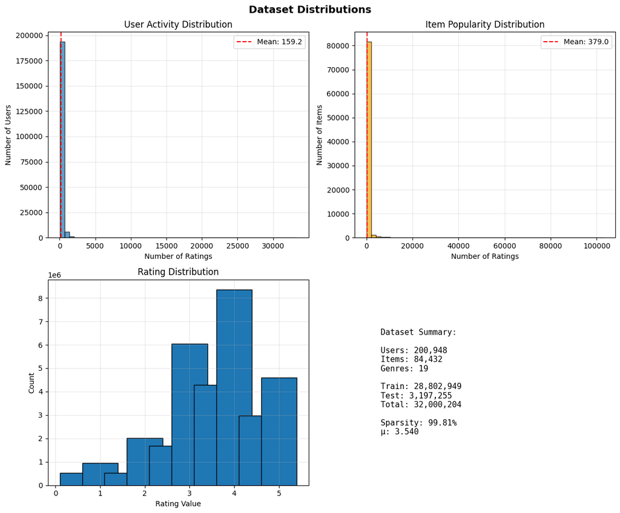

```
2. POWER LAW ANALYSIS
```

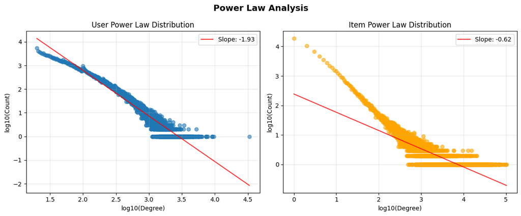

```
3. BIAS-ONLY MODEL
Initial RMSE: Train=1.0589, Test=1.0596
Epoch 5: Train=0.8462, Test=0.8558
Epoch 10: Train=0.8462, Test=0.8558
```

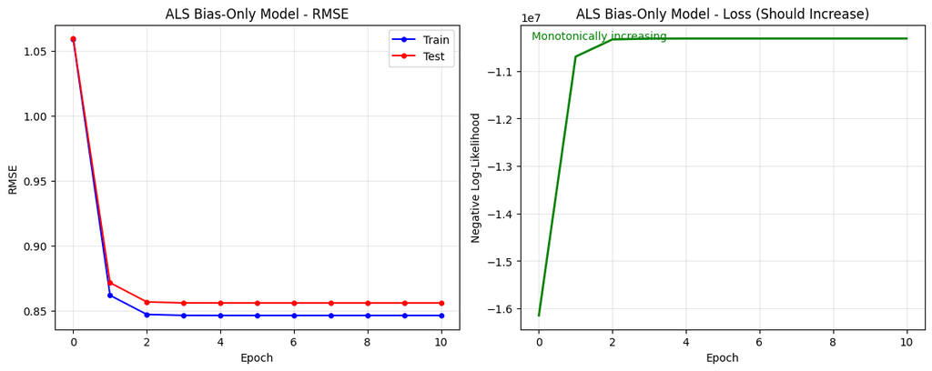

```
4. HYPERPARAMETER TUNING

============================================================
HYPERPARAMETER TUNING
============================================================
λ=0.1, γ=2.5, τ=1.0 -> Test RMSE: 0.7849
λ=0.2, γ=2.5, τ=1.0 -> Test RMSE: 0.7860
λ=0.1, γ=5.0, τ=2.0 -> Test RMSE: 0.7864

Best params: λ=0.1, γ=2.5, τ=1.0
Best RMSE: 0.7849

5. DIMENSION ANALYSIS

============================================================
DIMENSION ANALYSIS
============================================================
D= 2 -> Train: 0.7988, Test: 0.8162
D= 5 -> Train: 0.7617, Test: 0.7940
D=10 -> Train: 0.7224, Test: 0.7787
D=20 -> Train: 0.6743, Test: 0.7738
D=50 -> Train: 0.5927, Test: 0.8032
```

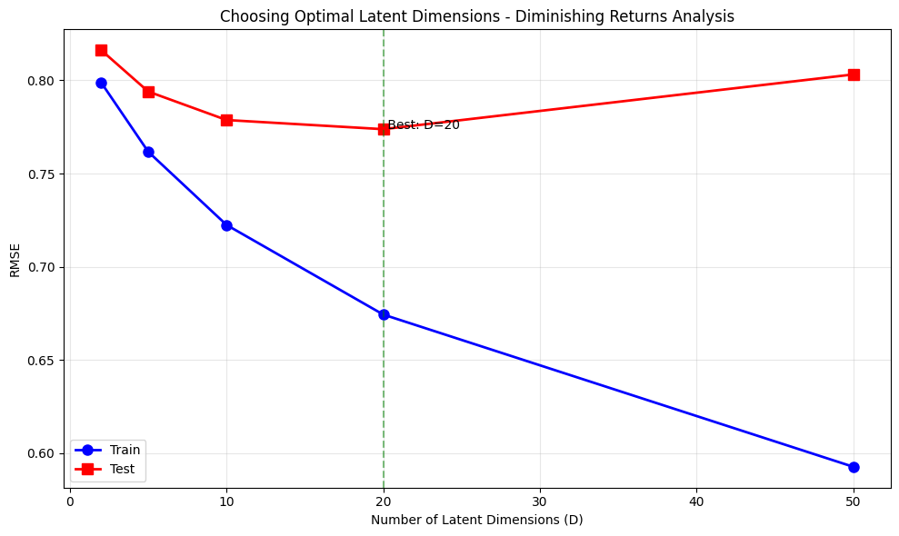

```
6. FULL ALS LATENT MODEL
Initial RMSE: Train=1.0824, Test=1.0831
Epoch 1: Time=50.3s, Train=0.8138, Test=0.8876
Epoch 5: Time=54.7s, Train=0.6833, Test=0.7817
Epoch 10: Time=54.8s, Train=0.6743, Test=0.7738
Epoch 15: Time=56.4s, Train=0.6726, Test=0.7723
Epoch 20: Time=59.5s, Train=0.6721, Test=0.7716
```

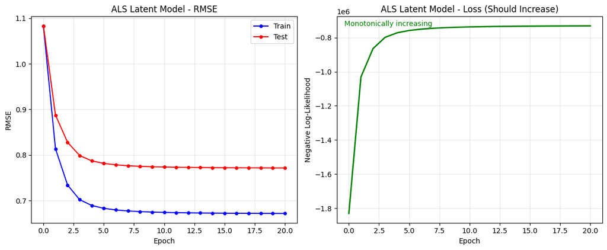

```
7. VARIATIONAL INFERENCE MODEL

Variational Inference with Cholesky
D=20, λ=0.1, τ=1.0, γ=2.5
Initial RMSE: Train=1.0824, Test=1.0831
Epoch 1: Time=478.5s, Train=0.8607, Test=0.8692, ELBO=-2032971
Epoch 10: Time=504.2s, Train=0.8430, Test=0.8498, ELBO=-1680830
Epoch 20: Time=478.9s, Train=0.8389, Test=0.8460, ELBO=-1679602
```

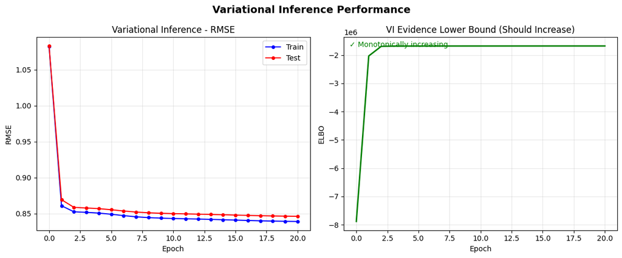

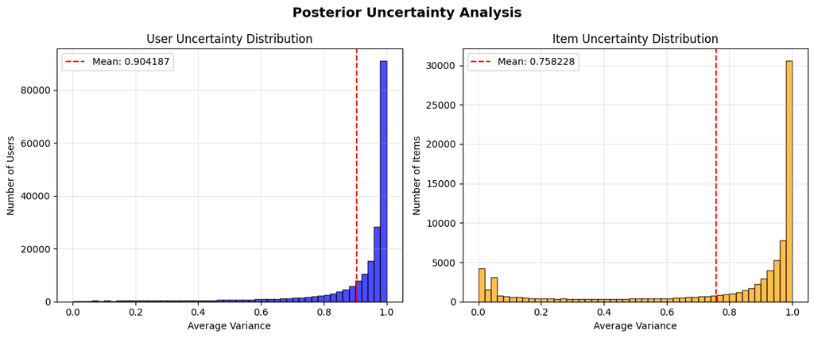

```
============================================================
UNCERTAINTY ANALYSIS
============================================================

Most Certain Items (Low Variance):
 1. Shawshank Redemption, The (1994)                   | σ²=0.000122 | Ratings=102929
 2. Forrest Gump (1994)                                | σ²=0.000127 | Ratings=100296
 3. Pulp Fiction (1994)                                | σ²=0.000129 | Ratings=98409
 4. Matrix, The (1999)                                 | σ²=0.000138 | Ratings=93808
 5. Silence of the Lambs, The (1991)                   | σ²=0.000141 | Ratings=90330
 6. Star Wars: Episode IV - A New Hope (1977)          | σ²=0.000151 | Ratings=85010
 7. Fight Club (1999)                                  | σ²=0.000169 | Ratings=77332
 8. Jurassic Park (1993)                               | σ²=0.000170 | Ratings=75233
 9. Schindler's List (1993)                            | σ²=0.000172 | Ratings=73849
10. Lord of the Rings: The Fellowship of the Ring, The | σ²=0.000180 | Ratings=73122

Most Uncertain Items (High Variance):
 1. Caravaggio (2007)                                  | σ²=0.999944 | Ratings=2
 2. The Opponent (1988)                                | σ²=0.999944 | Ratings=1
 3. Nobody To Watch Over Me (2008)                     | σ²=0.999944 | Ratings=2
 4. The Summit: A Chronicle Of Stones to Serenity (200 | σ²=0.999944 | Ratings=1
 5. Couple in a Hole (2016)                            | σ²=0.999944 | Ratings=1
 6. Dawn of the Felines (2017)                         | σ²=0.999944 | Ratings=1
 7. Movie Days (Bíódagar) (1994)                       | σ²=0.999944 | Ratings=3
 8. On the Edge (2011)                                 | σ²=0.999944 | Ratings=2
 9. The Red Awn (2007)                                 | σ²=0.999944 | Ratings=1
10. The Owners (2014)                                  | σ²=0.999944 | Ratings=1

Cold Start Items (≤5 ratings): Mean σ² = 0.937737
Popular Items (≥1000 ratings): Mean σ² = 0.007721

8. MOVIE EMBEDDINGS BY GENRE (2D)

Hierarchical ALS: D=2, λ=0.1, τ=1.0, β=1.0, γ=2.5
Genre features: 19 genres
Initial: Train=1.2663, Test=1.2672
Epoch 10: Train=0.7983, Test=0.8159
Epoch 20: Train=0.7980, Test=0.8155
Epoch 30: Train=0.7981, Test=0.8155
Epoch 40: Train=0.7982, Test=0.8155
Epoch 50: Train=0.7983, Test=0.8155
```

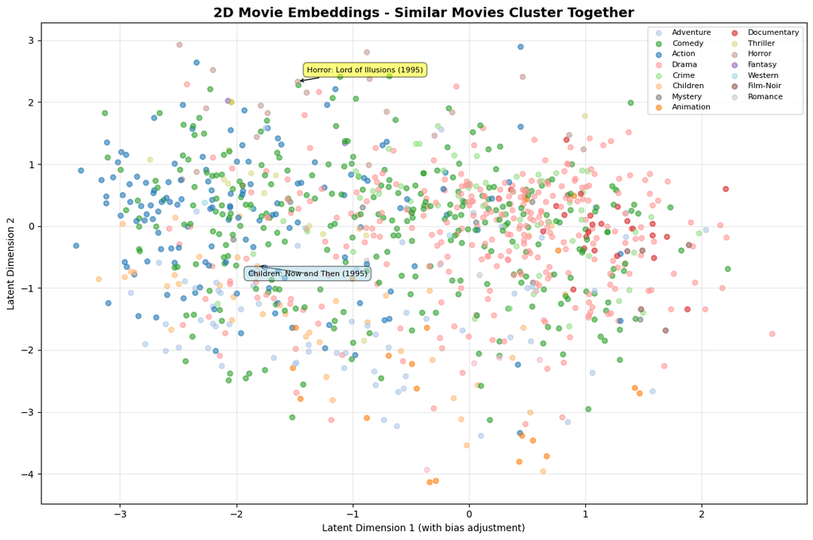

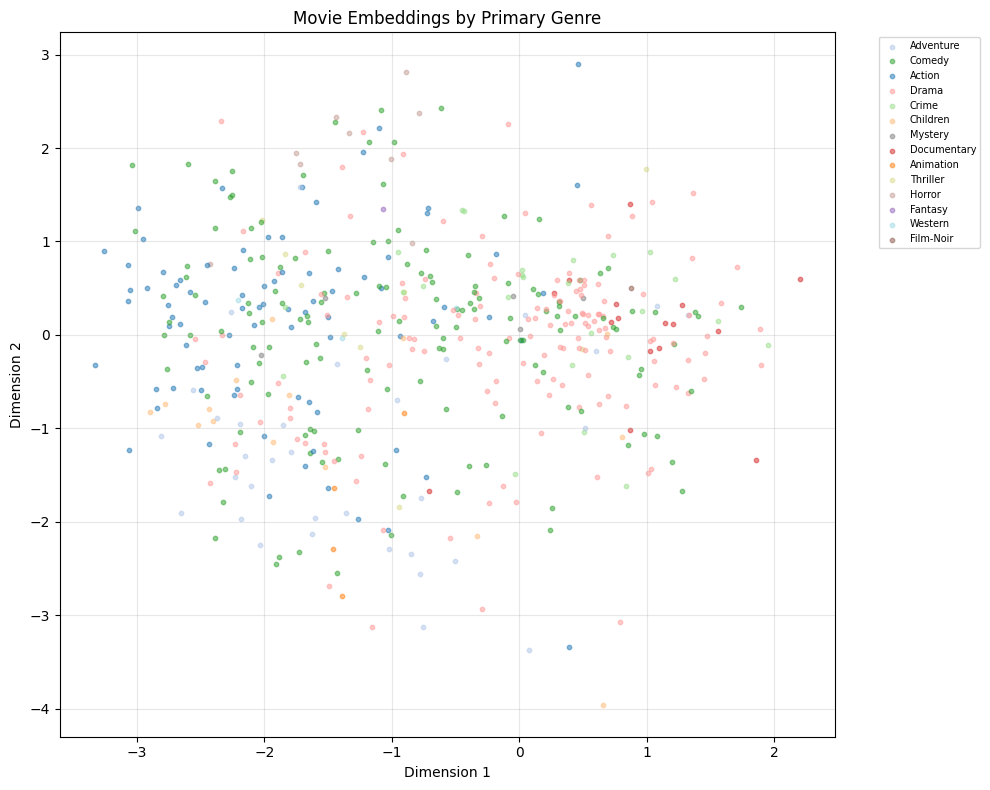

```
9. FEATURE EMBEDDINGS
```

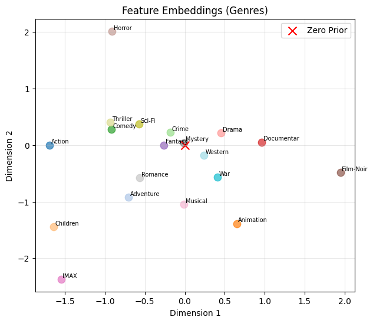

```
10. HIERARCHICAL ALS WITH FEATURES

Hierarchical ALS: D=20, λ=0.1, τ=1.0, β=1.0, γ=2.5
Genre features: 19 genres
Initial: Train=1.0824, Test=1.0831
Epoch 10: Train=0.6730, Test=0.7729
Epoch 20: Train=0.6701, Test=0.7705
Epoch 30: Train=0.6695, Test=0.7703
Epoch 40: Train=0.6692, Test=0.7705
Epoch 50: Train=0.6691, Test=0.7708
```

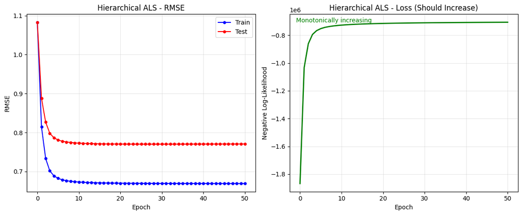

```
11. COLD START DEMONSTRATION

============================================================
COLD START DEMONSTRATION
============================================================
Found 31170 movies with ≤3 ratings but with genres

Simulating new 'Adventure + Animation' movie...
Predicted embedding norm: 3.530

Most similar existing movies:
1. Turtle's Tale: Sammy's Adventures, A (2010) (similarity: 0.994)
2. Long Way North (2016) (similarity: 0.992)
3. Mary and the Witch's Flower (2017) (similarity: 0.989)
4. The Rabbi's Cat (Le chat du rabbin) (2011) (similarity: 0.989)
5. Pokémon Origins (2013) (similarity: 0.985)

12. RECOMMENDATIONS

Recommendations for users who liked: Lord of the Rings: The Fellowship of the Ring, The (2001)
------------------------------------------------------------
 1. Lord of the Rings: The Return of the King, The (2003)        | Score: 88.591
 2. Lord of the Rings: The Fellowship of the Ring, The (2001)    | Score: 87.162
 3. Lord of the Rings: The Two Towers, The (2002)                | Score: 87.131
 4. Hobbit: An Unexpected Journey, The (2012)                    | Score: 53.351
 5. Hobbit: The Desolation of Smaug, The (2013)                  | Score: 47.635
 6. The Hobbit: The Battle of the Five Armies (2014)             | Score: 43.630
 7. Braveheart (1995)                                            | Score: 30.724
 8. Star Wars: Episode III - Revenge of the Sith (2005)          | Score: 30.342
 9. Blair Witch Project, The (1999)                              | Score: 30.050
10. Pirates of the Caribbean: The Curse of the Black Pearl (2003 | Score: 30.031

13. RECOMMENDATIONS COMPARISON

Recommendations for users who liked: Lord of the Rings: The Fellowship of the Ring, The (2001)
------------------------------------------------------------
 1. Lord of the Rings: The Return of the King, The (2003)        | Score: 109.175
 2. Lord of the Rings: The Two Towers, The (2002)                | Score: 107.998
 3. Lord of the Rings: The Fellowship of the Ring, The (2001)    | Score: 107.973
 4. Hobbit: An Unexpected Journey, The (2012)                    | Score: 69.311
```

[output cut: 43 more lines]

```
 4. Richard Says Goodbye (2018)                        | ||v||=0.833
 5. Grandma (2015)                                     | ||v||=0.831
 6. Rams (2015)                                        | ||v||=0.751
 7. The Hummingbird Project (2018)                     | ||v||=0.723
 8. Kedi (2016)                                        | ||v||=0.697
 9. Krisha (2015)                                      | ||v||=0.687
10. Salyut 7 (2017)                                    | ||v||=0.334

16. BAYESIAN PERSONALIZED RANKING
Training BPR for 50 epochs on 200695 active users
Epoch  10/50 | Time: 133.7s | Loss: 0.0416 | AUC: 0.9891
Epoch  20/50 | Time: 156.5s | Loss: 0.0337 | AUC: 0.9915
Epoch  30/50 | Time: 145.8s | Loss: 0.0297 | AUC: 0.9928
Epoch  40/50 | Time: 144.0s | Loss: 0.0273 | AUC: 0.9933
Epoch  50/50 | Time: 156.8s | Loss: 0.0258 | AUC: 0.9953
```

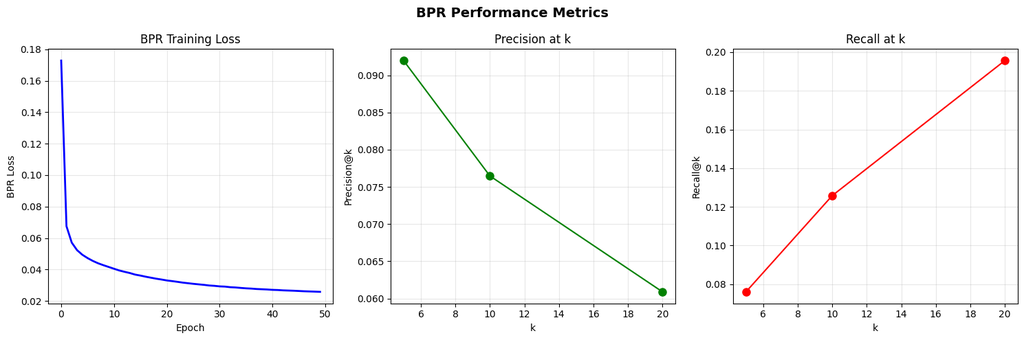

```
BPR Results:
Precision@5: 0.0920
Recall@5: 0.0760
Precision@10: 0.0765
Recall@10: 0.1258
Precision@20: 0.0609
Recall@20: 0.1957

17. A/B TESTING

============================================================
A/B TEST SIMULATION
============================================================
Group A (Control, n=99): Mean=4.7963
Group B (Test, n=101): Mean=4.4950
T-statistic: 8.4044
P-value: 0.0000
✓ Model A is significantly better (p < 0.05)
```

[1 more figures not shown]

```
============================================================
ANALYSIS COMPLETE
============================================================
 Best hyperparameters: λ=0.1, γ=2.5, τ=1.0
 Optimal dimensions: D=20
ALS Test RMSE: 0.7716
 VI Test RMSE: 0.8460
VI Mean Uncertainty - Users: 0.904187, Items: 0.758228
 Feature Model Test RMSE: 0.7708
============================================================
```

```python
if __name__ == "__main__":
    print("="*60)
    print(" ALS RECOMMENDER SYSTEM")
    print("="*60)

    data = DataLoader()

    # Please Here you can update these paths to your data location
    ratingspath = r"/Users/ahmed/Documents/rec/code/ml-32m/ratings.csv"
    moviespath = r"/Users/ahmed/Documents/rec/code/ml-32m/movies.csv"

    if not os.path.exists(ratingspath):
        print(f"ERROR: Ratings file not found at: {ratingspath}")
        exit(1)
    if not os.path.exists(moviespath):
        print(f"ERROR: Movies file not found at: {moviespath}")
        exit(1)

    try:
        data.load(ratingspath, moviespath)
    except Exception as e:
        print(f"ERROR loading data: {e}")
        exit(1)

    checkconsistency(data)

    print("\n1. DATA DISTRIBUTIONS")
    plotdistributions(data)

    print("\n2. POWER LAW ANALYSIS")
    plotpowerlaws(data)

    print("\n3. BIAS-ONLY MODEL")
    biasmodel = BiasOnly(data)
    biasmodel.train(epochs=10)
    plotcurves(biasmodel, "ALS Bias-Only Model")

    print("\n4. HYPERPARAMETER TUNING")
    bestparams = tune(data)

    print("\n5. DIMENSION ANALYSIS")
    optimald = dimensionanalysis(data, bestparams)

    print("\n6. FULL ALS LATENT MODEL")
    alsmodel = Latent(data)
    alsmodel.train(D=optimald, epochs=20, **bestparams)
    plotcurves(alsmodel, "ALS Latent Model")

    print("\n7. VARIATIONAL INFERENCE MODEL")
    vimodel = VI(data)
    vimodel.train(D=optimald, epochs=20, **bestparams)
    plotvi(vimodel)
    plotuncertainty(vimodel)
    analyzeuncertainty(vimodel, data)


    print("\n8. MOVIE EMBEDDINGS BY GENRE (2D)")
    featuremodel2d = Features(data)
    featuremodel2d.train(D=2, epochs=50,
                         lam=bestparams['lam'],
                         tau=bestparams['tau'],
                         gam=bestparams['gam'],
                         beta=1.0)
    plotembeddings2d(featuremodel2d, data)
    plotmovieembeddings(featuremodel2d, data)


    print("\n9. FEATURE EMBEDDINGS")
    plotfeatureembeddings(featuremodel2d, data)

    print("\n10. HIERARCHICAL ALS WITH FEATURES")
    featuremodel = Features(data)
    featuremodel.train(D=optimald, epochs=50,
                       lam=bestparams['lam'],
                       tau=bestparams['tau'],
                       gam=bestparams['gam'],
                       beta=1.0)
    plotcurves(featuremodel, "Hierarchical ALS")


    print("\n11. COLD START DEMONSTRATION")
    coldstartdemo(featuremodel, data)

    print("\n12. RECOMMENDATIONS")
    recommender = Recommender(alsmodel, data)
    popular = [(i, data.counts[i]) for i in range(data.N)]
    popular.sort(key=lambda x: x[1], reverse=True)
    if len(popular) > 0:
        movieidx = popular[0][0]
        movieid = data.itemlist[movieidx]
        recommendations = recommender.recommendformovie(4993, topk=10)  # Our lord of the Rings movie with id 4993

    print("\n13. RECOMMENDATIONS COMPARISON")
    recommender = Recommender(featuremodel, data)
    recommendations = recommender.recommendformovie(4993, topk=10)

    print("\n14. VI RECOMMENDATIONS WITH UNCERTAINTY")
    virecommendations = vimodel.recommend_with_uncertainty(100, topk=10)
    print("\nRecommendations with uncertainty for user 100:")
    for i, (movie_id, title, score) in enumerate(virecommendations, 1):
        print(f"{i:2}. {title[:60]:<60} | Score: {score:.3f}")

    print("\n15. POLARIZING MOVIES")
    findpolarizing(featuremodel, data)

    print("\n16. BAYESIAN PERSONALIZED RANKING")
    implicittrain = []
    implicittest = []
    for u in range(data.M):
        implicittrain.append([(i, 1) for i, r in data.train[u] if r >= 4.0])
        implicittest.append([(i, 1) for i, r in data.test[u] if r >= 4.0])

    bpr = BPR(data.M, data.N, factors=64, lr=0.05, regu=0.001, regi=0.001)
    bpr.fit(implicittrain, implicittest, epochs=50, evalevery=10)

    prresults = evalpr(bpr, implicittest, implicittrain)
    plotbpr(bpr, prresults)

    print(f"\nBPR Results:")
    print(f"Precision@5: {prresults['precision@5']:.4f}")
    print(f"Recall@5: {prresults['recall@5']:.4f}")
    print(f"Precision@10: {prresults['precision@10']:.4f}")
    print(f"Recall@10: {prresults['recall@10']:.4f}")
    print(f"Precision@20: {prresults['precision@20']:.4f}")
    print(f"Recall@20: {prresults['recall@20']:.4f}")

    print("\n17. A/B TESTING")
    abtest = ABTest(data)
    abresults = abtest.runtest(featuremodel, nusers=200)
    plotabtest(abtest)

    print("\n" + "="*60)
    print("ANALYSIS COMPLETE")
    print("="*60)
    print(f" Best hyperparameters: λ={bestparams['lam']}, γ={bestparams['gam']}, τ={bestparams['tau']}")
    print(f" Optimal dimensions: D={optimald}")
    print(f"ALS Test RMSE: {alsmodel.rmsetest[-1]:.4f}")
    print(f" VI Test RMSE: {vimodel.rmsetest[-1]:.4f}")
    print(f"VI Mean Uncertainty - Users: {np.mean(vimodel.sigma_U):.6f}, Items: {np.mean(vimodel.sigma_V):.6f}")
    print(f" Feature Model Test RMSE: {featuremodel.rmsetest[-1]:.4f}")
    print("="*60)
```